# Risk Factor Analysis

## Outcome Variable

**Outcome Variable:** ever_stunted

## Predictor Variables

**Intervention Variable:** gagebrth

**Adjustment Set:**

unadjusted

## Stratifying Variables

The analysis was stratified on these variable(s):

- agecat
- studyid
- country

## Data Summary

| agecat | studyid | country | A | n | nA | nAY0 | nAY1 |
| --- | --- | --- | --- | --- | --- | --- | --- |
| 3 months | ki1000108-CMC-V-BCS-2002 | INDIA | [273-287) | 340 | 142 | 102 | 40 |
| 3 months | ki1000108-CMC-V-BCS-2002 | INDIA | <259 | 340 | 46 | 24 | 22 |
| 3 months | ki1000108-CMC-V-BCS-2002 | INDIA | [259-273) | 340 | 74 | 45 | 29 |
| 3 months | ki1000108-CMC-V-BCS-2002 | INDIA | >=287 | 340 | 78 | 49 | 29 |
| 3 months | ki1000108-IRC | INDIA | [273-287) | 390 | 165 | 118 | 47 |
| 3 months | ki1000108-IRC | INDIA | <259 | 390 | 40 | 20 | 20 |
| 3 months | ki1000108-IRC | INDIA | [259-273) | 390 | 92 | 62 | 30 |
| 3 months | ki1000108-IRC | INDIA | >=287 | 390 | 93 | 64 | 29 |
| 3 months | ki1000109-EE | PAKISTAN | [273-287) | 379 | 24 | 13 | 11 |
| 3 months | ki1000109-EE | PAKISTAN | <259 | 379 | 245 | 78 | 167 |
| 3 months | ki1000109-EE | PAKISTAN | [259-273) | 379 | 109 | 46 | 63 |
| 3 months | ki1000109-EE | PAKISTAN | >=287 | 379 | 1 | 1 | 0 |
| 3 months | ki1000304b-SAS-CompFeed | INDIA | [273-287) | 469 | 12 | 9 | 3 |
| 3 months | ki1000304b-SAS-CompFeed | INDIA | <259 | 469 | 366 | 236 | 130 |
| 3 months | ki1000304b-SAS-CompFeed | INDIA | [259-273) | 469 | 89 | 66 | 23 |
| 3 months | ki1000304b-SAS-CompFeed | INDIA | >=287 | 469 | 2 | 2 | 0 |
| 3 months | ki1017093c-NIH-Crypto | BANGLADESH | [273-287) | 758 | 251 | 231 | 20 |
| 3 months | ki1017093c-NIH-Crypto | BANGLADESH | <259 | 758 | 157 | 100 | 57 |
| 3 months | ki1017093c-NIH-Crypto | BANGLADESH | [259-273) | 758 | 330 | 286 | 44 |
| 3 months | ki1017093c-NIH-Crypto | BANGLADESH | >=287 | 758 | 20 | 20 | 0 |
| 3 months | ki1066203-TanzaniaChild2 | TANZANIA, UNITED REPUBLIC OF | [273-287) | 2251 | 884 | 802 | 82 |
| 3 months | ki1066203-TanzaniaChild2 | TANZANIA, UNITED REPUBLIC OF | <259 | 2251 | 324 | 264 | 60 |
| 3 months | ki1066203-TanzaniaChild2 | TANZANIA, UNITED REPUBLIC OF | [259-273) | 2251 | 471 | 420 | 51 |
| 3 months | ki1066203-TanzaniaChild2 | TANZANIA, UNITED REPUBLIC OF | >=287 | 2251 | 572 | 533 | 39 |
| 3 months | ki1101329-Keneba | GAMBIA | [273-287) | 1558 | 608 | 507 | 101 |
| 3 months | ki1101329-Keneba | GAMBIA | <259 | 1558 | 165 | 98 | 67 |
| 3 months | ki1101329-Keneba | GAMBIA | [259-273) | 1558 | 608 | 465 | 143 |
| 3 months | ki1101329-Keneba | GAMBIA | >=287 | 1558 | 177 | 153 | 24 |
| 3 months | ki1113344-GMS-Nepal | NEPAL | [273-287) | 593 | 0 | 0 | 0 |
| 3 months | ki1113344-GMS-Nepal | NEPAL | <259 | 593 | 1 | 0 | 1 |

[output cut: 218 more lines]

The following strata were considered:

- agecat: 12 months, studyid: ki1000108-CMC-V-BCS-2002, country: INDIA
- agecat: 12 months, studyid: ki1000108-IRC, country: INDIA
- agecat: 12 months, studyid: ki1000109-EE, country: PAKISTAN
- agecat: 12 months, studyid: ki1000304b-SAS-CompFeed, country: INDIA
- agecat: 12 months, studyid: ki1017093c-NIH-Crypto, country: BANGLADESH
- agecat: 12 months, studyid: ki1066203-TanzaniaChild2, country: TANZANIA, UNITED REPUBLIC OF
- agecat: 12 months, studyid: ki1101329-Keneba, country: GAMBIA
- agecat: 12 months, studyid: ki1113344-GMS-Nepal, country: NEPAL
- agecat: 12 months, studyid: ki1119695-PROBIT, country: BELARUS
- agecat: 12 months, studyid: ki1135781-COHORTS, country: GUATEMALA
- agecat: 12 months, studyid: ki1135781-COHORTS, country: INDIA
- agecat: 12 months, studyid: ki1135781-COHORTS, country: PHILIPPINES
- agecat: 12 months, studyid: kiGH5241-JiVitA-3, country: BANGLADESH
- agecat: 18 months, studyid: ki1000108-CMC-V-BCS-2002, country: INDIA
- agecat: 18 months, studyid: ki1000108-IRC, country: INDIA
- agecat: 18 months, studyid: ki1000109-EE, country: PAKISTAN
- agecat: 18 months, studyid: ki1000304b-SAS-CompFeed, country: INDIA
- agecat: 18 months, studyid: ki1017093c-NIH-Crypto, country: BANGLADESH
- agecat: 18 months, studyid: ki1066203-TanzaniaChild2, country: TANZANIA, UNITED REPUBLIC OF
- agecat: 18 months, studyid: ki1101329-Keneba, country: GAMBIA
- agecat: 18 months, studyid: ki1113344-GMS-Nepal, country: NEPAL
- agecat: 18 months, studyid: ki1119695-PROBIT, country: BELARUS
- agecat: 18 months, studyid: ki1135781-COHORTS, country: GUATEMALA
- agecat: 18 months, studyid: ki1135781-COHORTS, country: PHILIPPINES
- agecat: 18 months, studyid: kiGH5241-JiVitA-3, country: BANGLADESH
- agecat: 24 months, studyid: ki1000108-CMC-V-BCS-2002, country: INDIA
- agecat: 24 months, studyid: ki1000108-IRC, country: INDIA
- agecat: 24 months, studyid: ki1000109-EE, country: PAKISTAN
- agecat: 24 months, studyid: ki1000304b-SAS-CompFeed, country: INDIA
- agecat: 24 months, studyid: ki1017093c-NIH-Crypto, country: BANGLADESH
- agecat: 24 months, studyid: ki1066203-TanzaniaChild2, country: TANZANIA, UNITED REPUBLIC OF
- agecat: 24 months, studyid: ki1101329-Keneba, country: GAMBIA
- agecat: 24 months, studyid: ki1113344-GMS-Nepal, country: NEPAL
- agecat: 24 months, studyid: ki1119695-PROBIT, country: BELARUS
- agecat: 24 months, studyid: ki1135781-COHORTS, country: GUATEMALA
- agecat: 24 months, studyid: ki1135781-COHORTS, country: PHILIPPINES
- agecat: 24 months, studyid: kiGH5241-JiVitA-3, country: BANGLADESH
- agecat: 3 months, studyid: ki1000108-CMC-V-BCS-2002, country: INDIA
- agecat: 3 months, studyid: ki1000108-IRC, country: INDIA
- agecat: 3 months, studyid: ki1000109-EE, country: PAKISTAN
- agecat: 3 months, studyid: ki1000304b-SAS-CompFeed, country: INDIA
- agecat: 3 months, studyid: ki1017093c-NIH-Crypto, country: BANGLADESH
- agecat: 3 months, studyid: ki1066203-TanzaniaChild2, country: TANZANIA, UNITED REPUBLIC OF
- agecat: 3 months, studyid: ki1101329-Keneba, country: GAMBIA
- agecat: 3 months, studyid: ki1113344-GMS-Nepal, country: NEPAL
- agecat: 3 months, studyid: ki1119695-PROBIT, country: BELARUS
- agecat: 3 months, studyid: ki1135781-COHORTS, country: GUATEMALA
- agecat: 3 months, studyid: ki1135781-COHORTS, country: INDIA
- agecat: 3 months, studyid: ki1135781-COHORTS, country: PHILIPPINES
- agecat: 3 months, studyid: kiGH5241-JiVitA-3, country: BANGLADESH
- agecat: 6 months, studyid: ki1000108-CMC-V-BCS-2002, country: INDIA
- agecat: 6 months, studyid: ki1000108-IRC, country: INDIA
- agecat: 6 months, studyid: ki1000109-EE, country: PAKISTAN
- agecat: 6 months, studyid: ki1000304b-SAS-CompFeed, country: INDIA
- agecat: 6 months, studyid: ki1017093c-NIH-Crypto, country: BANGLADESH
- agecat: 6 months, studyid: ki1066203-TanzaniaChild2, country: TANZANIA, UNITED REPUBLIC OF
- agecat: 6 months, studyid: ki1101329-Keneba, country: GAMBIA
- agecat: 6 months, studyid: ki1113344-GMS-Nepal, country: NEPAL
- agecat: 6 months, studyid: ki1119695-PROBIT, country: BELARUS
- agecat: 6 months, studyid: ki1135781-COHORTS, country: GUATEMALA
- agecat: 6 months, studyid: ki1135781-COHORTS, country: PHILIPPINES
- agecat: 6 months, studyid: kiGH5241-JiVitA-3, country: BANGLADESH

### Dropped Strata

Some strata were dropped due to rare outcomes:

- agecat: 3 months, studyid: ki1000109-EE, country: PAKISTAN
- agecat: 3 months, studyid: ki1000304b-SAS-CompFeed, country: INDIA
- agecat: 3 months, studyid: ki1017093c-NIH-Crypto, country: BANGLADESH
- agecat: 3 months, studyid: ki1113344-GMS-Nepal, country: NEPAL
- agecat: 3 months, studyid: ki1119695-PROBIT, country: BELARUS
- agecat: 6 months, studyid: ki1000109-EE, country: PAKISTAN
- agecat: 6 months, studyid: ki1000304b-SAS-CompFeed, country: INDIA
- agecat: 6 months, studyid: ki1017093c-NIH-Crypto, country: BANGLADESH
- agecat: 6 months, studyid: ki1113344-GMS-Nepal, country: NEPAL
- agecat: 6 months, studyid: ki1119695-PROBIT, country: BELARUS
- agecat: 6 months, studyid: ki1135781-COHORTS, country: GUATEMALA
- agecat: 12 months, studyid: ki1000109-EE, country: PAKISTAN
- agecat: 12 months, studyid: ki1000304b-SAS-CompFeed, country: INDIA
- agecat: 12 months, studyid: ki1017093c-NIH-Crypto, country: BANGLADESH
- agecat: 12 months, studyid: ki1113344-GMS-Nepal, country: NEPAL
- agecat: 12 months, studyid: ki1119695-PROBIT, country: BELARUS
- agecat: 18 months, studyid: ki1000109-EE, country: PAKISTAN
- agecat: 18 months, studyid: ki1000304b-SAS-CompFeed, country: INDIA
- agecat: 18 months, studyid: ki1113344-GMS-Nepal, country: NEPAL
- agecat: 18 months, studyid: ki1119695-PROBIT, country: BELARUS
- agecat: 24 months, studyid: ki1000108-CMC-V-BCS-2002, country: INDIA
- agecat: 24 months, studyid: ki1000109-EE, country: PAKISTAN
- agecat: 24 months, studyid: ki1000304b-SAS-CompFeed, country: INDIA
- agecat: 24 months, studyid: ki1113344-GMS-Nepal, country: NEPAL
- agecat: 24 months, studyid: ki1119695-PROBIT, country: BELARUS
- agecat: 24 months, studyid: ki1135781-COHORTS, country: GUATEMALA
- agecat: 24 months, studyid: kiGH5241-JiVitA-3, country: BANGLADESH

## Methods Detail

We’re interested in the causal parameters $E[Y_a]$ for all values of $a \in \mathcal{A}$. These parameters represent the mean outcome if, possibly contrary to fact, we intervened to set all units to have $A=a$. Under the randomization and positivity assumptions, these are identified by the statistical parameters $\psi_a=E_W[E_{Y|A,W}(Y|A=a,W)]$. In addition, we’re interested in the mean of $Y$, $E[Y]$ under no intervention (the observed mean). We will estimate these parameters by using SuperLearner to fit the relevant likelihood factors – $E_{Y|A,W}(Y|A=a,W)$ and $p(A=a|W)$, and then updating our likelihood fit using a joint TMLE.

For unadjusted analyses ($W=\{\}$), initial likelihoods were estimated using Lrnr_glm to estimate the simple $E(Y|A)$ and Lrnr_mean to estimate $p(A)$. For adjusted analyses, a small library containing Lrnr_glmnet, Lrnr_xgboost, and Lrnr_mean was used.

Having estimated these parameters, we will then use the delta method to estimate relative risks and attributable risks relative to a prespecified baseline level of $A$.

# Results Detail

## Results Plots

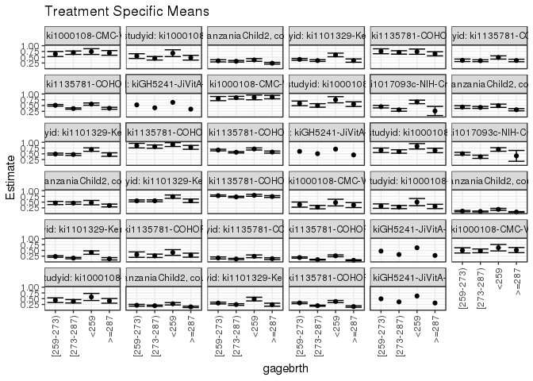

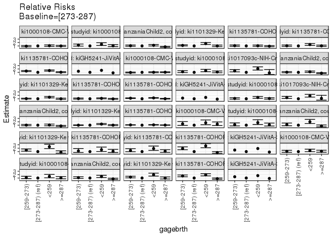

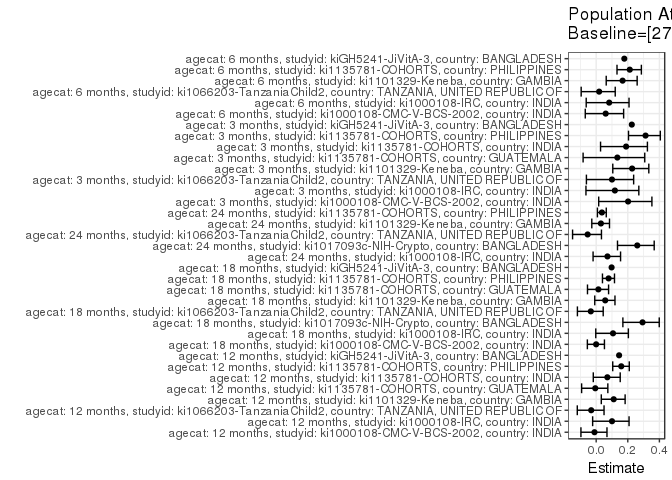

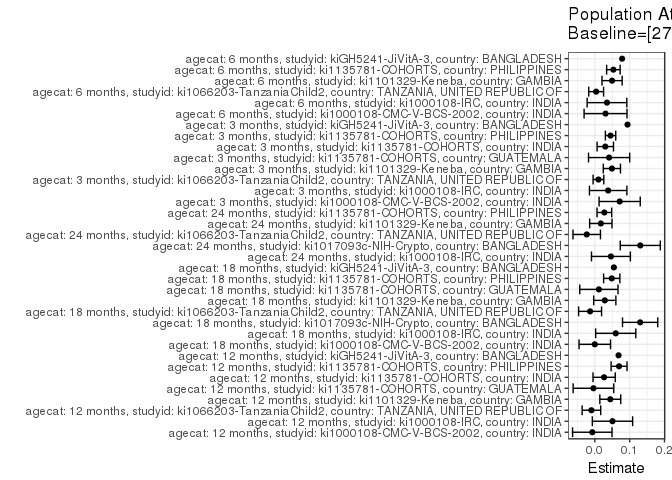

## Results Table

### Parameter: TSM

| agecat | studyid | country | intervention_level | baseline_level | estimate | ci_lower | ci_upper |
| --- | --- | --- | --- | --- | --- | --- | --- |
| 3 months | ki1000108-CMC-V-BCS-2002 | INDIA | [273-287) | NA | 0.2816901 | 0.2075958 | 0.3557845 |
| 3 months | ki1000108-CMC-V-BCS-2002 | INDIA | <259 | NA | 0.4782609 | 0.3336943 | 0.6228275 |
| 3 months | ki1000108-CMC-V-BCS-2002 | INDIA | [259-273) | NA | 0.3918919 | 0.2805021 | 0.5032817 |
| 3 months | ki1000108-CMC-V-BCS-2002 | INDIA | >=287 | NA | 0.3717949 | 0.2643853 | 0.4792044 |
| 3 months | ki1000108-IRC | INDIA | [273-287) | NA | 0.2848485 | 0.2158929 | 0.3538041 |
| 3 months | ki1000108-IRC | INDIA | <259 | NA | 0.5000000 | 0.3448522 | 0.6551478 |
| 3 months | ki1000108-IRC | INDIA | [259-273) | NA | 0.3260870 | 0.2301733 | 0.4220006 |
| 3 months | ki1000108-IRC | INDIA | >=287 | NA | 0.3118280 | 0.2175587 | 0.4060972 |
| 3 months | ki1066203-TanzaniaChild2 | TANZANIA, UNITED REPUBLIC OF | [273-287) | NA | 0.0927602 | 0.0736326 | 0.1118878 |
| 3 months | ki1066203-TanzaniaChild2 | TANZANIA, UNITED REPUBLIC OF | <259 | NA | 0.1851852 | 0.1428789 | 0.2274914 |
| 3 months | ki1066203-TanzaniaChild2 | TANZANIA, UNITED REPUBLIC OF | [259-273) | NA | 0.1082803 | 0.0802115 | 0.1363490 |
| 3 months | ki1066203-TanzaniaChild2 | TANZANIA, UNITED REPUBLIC OF | >=287 | NA | 0.0681818 | 0.0475211 | 0.0888426 |
| 3 months | ki1101329-Keneba | GAMBIA | [273-287) | NA | 0.1661184 | 0.1365249 | 0.1957120 |
| 3 months | ki1101329-Keneba | GAMBIA | <259 | NA | 0.4060606 | 0.3311036 | 0.4810176 |
| 3 months | ki1101329-Keneba | GAMBIA | [259-273) | NA | 0.2351974 | 0.2014743 | 0.2689204 |
| 3 months | ki1101329-Keneba | GAMBIA | >=287 | NA | 0.1355932 | 0.0851412 | 0.1860453 |
| 3 months | ki1135781-COHORTS | GUATEMALA | [273-287) | NA | 0.2642857 | 0.1911435 | 0.3374279 |
| 3 months | ki1135781-COHORTS | GUATEMALA | <259 | NA | 0.4098361 | 0.2862507 | 0.5334214 |
| 3 months | ki1135781-COHORTS | GUATEMALA | [259-273) | NA | 0.3166667 | 0.1988023 | 0.4345310 |
| 3 months | ki1135781-COHORTS | GUATEMALA | >=287 | NA | 0.2924528 | 0.2057380 | 0.3791676 |
| 3 months | ki1135781-COHORTS | INDIA | [273-287) | NA | 0.1283019 | 0.0998199 | 0.1567839 |
| 3 months | ki1135781-COHORTS | INDIA | <259 | NA | 0.2437811 | 0.1844019 | 0.3031603 |
| 3 months | ki1135781-COHORTS | INDIA | [259-273) | NA | 0.1716172 | 0.1291471 | 0.2140873 |
| 3 months | ki1135781-COHORTS | INDIA | >=287 | NA | 0.1415094 | 0.1031868 | 0.1798321 |
| 3 months | ki1135781-COHORTS | PHILIPPINES | [273-287) | NA | 0.0991525 | 0.0820974 | 0.1162077 |
| 3 months | ki1135781-COHORTS | PHILIPPINES | <259 | NA | 0.2652174 | 0.2248695 | 0.3055653 |
| 3 months | ki1135781-COHORTS | PHILIPPINES | [259-273) | NA | 0.1904192 | 0.1637836 | 0.2170547 |
| 3 months | ki1135781-COHORTS | PHILIPPINES | >=287 | NA | 0.0702703 | 0.0490017 | 0.0915388 |
| 3 months | kiGH5241-JiVitA-3 | BANGLADESH | [273-287) | NA | 0.3224585 | NA | NA |
| 3 months | kiGH5241-JiVitA-3 | BANGLADESH | <259 | NA | 0.6147733 | NA | NA |

[output cut: 110 more lines]

### Parameter: E(Y)

| agecat | studyid | country | intervention_level | baseline_level | estimate | ci_lower | ci_upper |
| --- | --- | --- | --- | --- | --- | --- | --- |
| 3 months | ki1000108-CMC-V-BCS-2002 | INDIA | NA | NA | 0.3529412 | 0.3020701 | 0.4038123 |
| 3 months | ki1000108-IRC | INDIA | NA | NA | 0.3230769 | 0.2766044 | 0.3695494 |
| 3 months | ki1066203-TanzaniaChild2 | TANZANIA, UNITED REPUBLIC OF | NA | NA | 0.1030653 | 0.0905023 | 0.1156283 |
| 3 months | ki1101329-Keneba | GAMBIA | NA | NA | 0.2150193 | 0.1946126 | 0.2354259 |
| 3 months | ki1135781-COHORTS | GUATEMALA | NA | NA | 0.3051771 | 0.2580012 | 0.3523531 |
| 3 months | ki1135781-COHORTS | INDIA | NA | NA | 0.1582840 | 0.1388205 | 0.1777476 |
| 3 months | ki1135781-COHORTS | PHILIPPINES | NA | NA | 0.1442244 | 0.1317133 | 0.1567356 |
| 3 months | kiGH5241-JiVitA-3 | BANGLADESH | NA | NA | 0.4162928 | NA | NA |
| 6 months | ki1000108-CMC-V-BCS-2002 | INDIA | NA | NA | 0.5101449 | 0.4573187 | 0.5629711 |
| 6 months | ki1000108-IRC | INDIA | NA | NA | 0.4226804 | 0.3734644 | 0.4718965 |
| 6 months | ki1066203-TanzaniaChild2 | TANZANIA, UNITED REPUBLIC OF | NA | NA | 0.1985714 | 0.1815054 | 0.2156375 |
| 6 months | ki1101329-Keneba | GAMBIA | NA | NA | 0.2959184 | 0.2725766 | 0.3192602 |
| 6 months | ki1135781-COHORTS | PHILIPPINES | NA | NA | 0.2500898 | 0.2339974 | 0.2661823 |
| 6 months | kiGH5241-JiVitA-3 | BANGLADESH | NA | NA | 0.4396636 | NA | NA |
| 12 months | ki1000108-CMC-V-BCS-2002 | INDIA | NA | NA | 0.6885714 | 0.6399879 | 0.7371550 |
| 12 months | ki1000108-IRC | INDIA | NA | NA | 0.5051546 | 0.4553420 | 0.5549673 |
| 12 months | ki1066203-TanzaniaChild2 | TANZANIA, UNITED REPUBLIC OF | NA | NA | 0.3155650 | 0.2945293 | 0.3366008 |
| 12 months | ki1101329-Keneba | GAMBIA | NA | NA | 0.3990796 | 0.3744609 | 0.4236982 |
| 12 months | ki1135781-COHORTS | GUATEMALA | NA | NA | 0.7043011 | 0.6578640 | 0.7507382 |
| 12 months | ki1135781-COHORTS | INDIA | NA | NA | 0.3757530 | 0.3496950 | 0.4018111 |
| 12 months | ki1135781-COHORTS | PHILIPPINES | NA | NA | 0.4381613 | 0.4195834 | 0.4567391 |
| 12 months | kiGH5241-JiVitA-3 | BANGLADESH | NA | NA | 0.4691693 | NA | NA |
| 18 months | ki1000108-CMC-V-BCS-2002 | INDIA | NA | NA | 0.8376068 | 0.7989685 | 0.8762451 |
| 18 months | ki1000108-IRC | INDIA | NA | NA | 0.5629820 | 0.5136272 | 0.6123368 |
| 18 months | ki1017093c-NIH-Crypto | BANGLADESH | NA | NA | 0.4433566 | 0.4069178 | 0.4797954 |
| 18 months | ki1066203-TanzaniaChild2 | TANZANIA, UNITED REPUBLIC OF | NA | NA | 0.4045355 | 0.3785082 | 0.4305628 |
| 18 months | ki1101329-Keneba | GAMBIA | NA | NA | 0.4989817 | 0.4734392 | 0.5245242 |
| 18 months | ki1135781-COHORTS | GUATEMALA | NA | NA | 0.8235294 | 0.7807461 | 0.8663127 |
| 18 months | ki1135781-COHORTS | PHILIPPINES | NA | NA | 0.6168582 | 0.5982037 | 0.6355127 |
| 18 months | kiGH5241-JiVitA-3 | BANGLADESH | NA | NA | 0.5600940 | NA | NA |
| 24 months | ki1000108-IRC | INDIA | NA | NA | 0.6461538 | 0.5986369 | 0.6936708 |
| 24 months | ki1017093c-NIH-Crypto | BANGLADESH | NA | NA | 0.5015773 | 0.4626267 | 0.5405279 |
| 24 months | ki1066203-TanzaniaChild2 | TANZANIA, UNITED REPUBLIC OF | NA | NA | 0.4326711 | 0.4003921 | 0.4649501 |
| 24 months | ki1101329-Keneba | GAMBIA | NA | NA | 0.5733057 | 0.5478042 | 0.5988072 |
| 24 months | ki1135781-COHORTS | PHILIPPINES | NA | NA | 0.7523622 | 0.7355727 | 0.7691517 |

### Parameter: RR

| agecat | studyid | country | intervention_level | baseline_level | estimate | ci_lower | ci_upper |
| --- | --- | --- | --- | --- | --- | --- | --- |
| 3 months | ki1000108-CMC-V-BCS-2002 | INDIA | [273-287) | [273-287) | 1.0000000 | 1.0000000 | 1.0000000 |
| 3 months | ki1000108-CMC-V-BCS-2002 | INDIA | <259 | [273-287) | 1.6978261 | 1.1372941 | 2.5346245 |
| 3 months | ki1000108-CMC-V-BCS-2002 | INDIA | [259-273) | [273-287) | 1.3912162 | 0.9445081 | 2.0491963 |
| 3 months | ki1000108-CMC-V-BCS-2002 | INDIA | >=287 | [273-287) | 1.3198718 | 0.8930018 | 1.9507930 |
| 3 months | ki1000108-IRC | INDIA | [273-287) | [273-287) | 1.0000000 | 1.0000000 | 1.0000000 |
| 3 months | ki1000108-IRC | INDIA | <259 | [273-287) | 1.7553191 | 1.1842339 | 2.6018046 |
| 3 months | ki1000108-IRC | INDIA | [259-273) | [273-287) | 1.1447734 | 0.7821287 | 1.6755632 |
| 3 months | ki1000108-IRC | INDIA | >=287 | [273-287) | 1.0947152 | 0.7431951 | 1.6124990 |
| 3 months | ki1066203-TanzaniaChild2 | TANZANIA, UNITED REPUBLIC OF | [273-287) | [273-287) | 1.0000000 | 1.0000000 | 1.0000000 |
| 3 months | ki1066203-TanzaniaChild2 | TANZANIA, UNITED REPUBLIC OF | <259 | [273-287) | 1.9963866 | 1.4675384 | 2.7158128 |
| 3 months | ki1066203-TanzaniaChild2 | TANZANIA, UNITED REPUBLIC OF | [259-273) | [273-287) | 1.1673140 | 0.8381734 | 1.6257040 |
| 3 months | ki1066203-TanzaniaChild2 | TANZANIA, UNITED REPUBLIC OF | >=287 | [273-287) | 0.7350333 | 0.5094775 | 1.0604470 |
| 3 months | ki1101329-Keneba | GAMBIA | [273-287) | [273-287) | 1.0000000 | 1.0000000 | 1.0000000 |
| 3 months | ki1101329-Keneba | GAMBIA | <259 | [273-287) | 2.4444044 | 1.8912976 | 3.1592665 |
| 3 months | ki1101329-Keneba | GAMBIA | [259-273) | [273-287) | 1.4158416 | 1.1264190 | 1.7796285 |
| 3 months | ki1101329-Keneba | GAMBIA | >=287 | [273-287) | 0.8162443 | 0.5403307 | 1.2330500 |
| 3 months | ki1135781-COHORTS | GUATEMALA | [273-287) | [273-287) | 1.0000000 | 1.0000000 | 1.0000000 |
| 3 months | ki1135781-COHORTS | GUATEMALA | <259 | [273-287) | 1.5507311 | 1.0298665 | 2.3350278 |
| 3 months | ki1135781-COHORTS | GUATEMALA | [259-273) | [273-287) | 1.1981982 | 0.7535197 | 1.9052972 |
| 3 months | ki1135781-COHORTS | GUATEMALA | >=287 | [273-287) | 1.1065783 | 0.7376203 | 1.6600892 |
| 3 months | ki1135781-COHORTS | INDIA | [273-287) | [273-287) | 1.0000000 | 1.0000000 | 1.0000000 |
| 3 months | ki1135781-COHORTS | INDIA | <259 | [273-287) | 1.9000585 | 1.3665985 | 2.6417579 |
| 3 months | ki1135781-COHORTS | INDIA | [259-273) | [273-287) | 1.3376043 | 0.9592840 | 1.8651258 |
| 3 months | ki1135781-COHORTS | INDIA | >=287 | [273-287) | 1.1029412 | 0.7770959 | 1.5654172 |
| 3 months | ki1135781-COHORTS | PHILIPPINES | [273-287) | [273-287) | 1.0000000 | 1.0000000 | 1.0000000 |
| 3 months | ki1135781-COHORTS | PHILIPPINES | <259 | [273-287) | 2.6748421 | 2.1260322 | 3.3653207 |
| 3 months | ki1135781-COHORTS | PHILIPPINES | [259-273) | [273-287) | 1.9204668 | 1.5385845 | 2.3971336 |
| 3 months | ki1135781-COHORTS | PHILIPPINES | >=287 | [273-287) | 0.7087087 | 0.5003531 | 1.0038272 |
| 3 months | kiGH5241-JiVitA-3 | BANGLADESH | [273-287) | [273-287) | 1.0000000 | NA | NA |
| 3 months | kiGH5241-JiVitA-3 | BANGLADESH | <259 | [273-287) | 1.9065191 | NA | NA |

[output cut: 110 more lines]

### Parameter: PAR

| agecat | studyid | country | intervention_level | baseline_level | estimate | ci_lower | ci_upper |
| --- | --- | --- | --- | --- | --- | --- | --- |
| 3 months | ki1000108-CMC-V-BCS-2002 | INDIA | [273-287) | NA | 0.0712510 | 0.0121570 | 0.1303450 |
| 3 months | ki1000108-IRC | INDIA | [273-287) | NA | 0.0382284 | -0.0155415 | 0.0919984 |
| 3 months | ki1066203-TanzaniaChild2 | TANZANIA, UNITED REPUBLIC OF | [273-287) | NA | 0.0103051 | -0.0050680 | 0.0256783 |
| 3 months | ki1101329-Keneba | GAMBIA | [273-287) | NA | 0.0489008 | 0.0242295 | 0.0735722 |
| 3 months | ki1135781-COHORTS | GUATEMALA | [273-287) | NA | 0.0408914 | -0.0182168 | 0.0999996 |
| 3 months | ki1135781-COHORTS | INDIA | [273-287) | NA | 0.0299821 | 0.0064442 | 0.0535201 |
| 3 months | ki1135781-COHORTS | PHILIPPINES | [273-287) | NA | 0.0450719 | 0.0302109 | 0.0599329 |
| 3 months | kiGH5241-JiVitA-3 | BANGLADESH | [273-287) | NA | 0.0938343 | NA | NA |
| 6 months | ki1000108-CMC-V-BCS-2002 | INDIA | [273-287) | NA | 0.0306929 | -0.0309703 | 0.0923560 |
| 6 months | ki1000108-IRC | INDIA | [273-287) | NA | 0.0348016 | -0.0222130 | 0.0918162 |
| 6 months | ki1066203-TanzaniaChild2 | TANZANIA, UNITED REPUBLIC OF | [273-287) | NA | 0.0037185 | -0.0176338 | 0.0250708 |
| 6 months | ki1101329-Keneba | GAMBIA | [273-287) | NA | 0.0494645 | 0.0204933 | 0.0784356 |
| 6 months | ki1135781-COHORTS | PHILIPPINES | [273-287) | NA | 0.0531892 | 0.0337932 | 0.0725852 |
| 6 months | kiGH5241-JiVitA-3 | BANGLADESH | [273-287) | NA | 0.0782991 | NA | NA |
| 12 months | ki1000108-CMC-V-BCS-2002 | INDIA | [273-287) | NA | -0.0073745 | -0.0640330 | 0.0492840 |
| 12 months | ki1000108-IRC | INDIA | [273-287) | NA | 0.0506092 | -0.0072389 | 0.1084572 |
| 12 months | ki1066203-TanzaniaChild2 | TANZANIA, UNITED REPUBLIC OF | [273-287) | NA | -0.0099197 | -0.0365962 | 0.0167567 |
| 12 months | ki1101329-Keneba | GAMBIA | [273-287) | NA | 0.0442941 | 0.0142763 | 0.0743119 |
| 12 months | ki1135781-COHORTS | GUATEMALA | [273-287) | NA | -0.0040323 | -0.0623783 | 0.0543138 |
| 12 months | ki1135781-COHORTS | INDIA | [273-287) | NA | 0.0266069 | -0.0053469 | 0.0585607 |
| 12 months | ki1135781-COHORTS | PHILIPPINES | [273-287) | NA | 0.0695447 | 0.0466760 | 0.0924135 |
| 12 months | kiGH5241-JiVitA-3 | BANGLADESH | [273-287) | NA | 0.0680679 | NA | NA |
| 18 months | ki1000108-CMC-V-BCS-2002 | INDIA | [273-287) | NA | -0.0002310 | -0.0454757 | 0.0450137 |
| 18 months | ki1000108-IRC | INDIA | [273-287) | NA | 0.0599517 | 0.0023243 | 0.1175791 |
| 18 months | ki1017093c-NIH-Crypto | BANGLADESH | [273-287) | NA | 0.1300519 | 0.0794081 | 0.1806957 |
| 18 months | ki1066203-TanzaniaChild2 | TANZANIA, UNITED REPUBLIC OF | [273-287) | NA | -0.0137155 | -0.0466881 | 0.0192571 |
| 18 months | ki1101329-Keneba | GAMBIA | [273-287) | NA | 0.0284956 | -0.0033594 | 0.0603506 |
| 18 months | ki1135781-COHORTS | GUATEMALA | [273-287) | NA | 0.0115636 | -0.0433342 | 0.0664614 |
| 18 months | ki1135781-COHORTS | PHILIPPINES | [273-287) | NA | 0.0484989 | 0.0251272 | 0.0718706 |
| 18 months | kiGH5241-JiVitA-3 | BANGLADESH | [273-287) | NA | 0.0546732 | NA | NA |
| 24 months | ki1000108-IRC | INDIA | [273-287) | NA | 0.0461538 | -0.0097004 | 0.1020081 |
| 24 months | ki1017093c-NIH-Crypto | BANGLADESH | [273-287) | NA | 0.1304433 | 0.0728830 | 0.1880035 |
| 24 months | ki1066203-TanzaniaChild2 | TANZANIA, UNITED REPUBLIC OF | [273-287) | NA | -0.0233729 | -0.0628298 | 0.0160841 |
| 24 months | ki1101329-Keneba | GAMBIA | [273-287) | NA | 0.0171559 | -0.0149272 | 0.0492390 |
| 24 months | ki1135781-COHORTS | PHILIPPINES | [273-287) | NA | 0.0272626 | 0.0062461 | 0.0482791 |

### Parameter: PAF

| agecat | studyid | country | intervention_level | baseline_level | estimate | ci_lower | ci_upper |
| --- | --- | --- | --- | --- | --- | --- | --- |
| 3 months | ki1000108-CMC-V-BCS-2002 | INDIA | [273-287) | NA | 0.2018779 | 0.0159908 | 0.3526495 |
| 3 months | ki1000108-IRC | INDIA | [273-287) | NA | 0.1183261 | -0.0646834 | 0.2698780 |
| 3 months | ki1066203-TanzaniaChild2 | TANZANIA, UNITED REPUBLIC OF | [273-287) | NA | 0.0999863 | -0.0617783 | 0.2371057 |
| 3 months | ki1101329-Keneba | GAMBIA | [273-287) | NA | 0.2274254 | 0.1050911 | 0.3330365 |
| 3 months | ki1135781-COHORTS | GUATEMALA | [273-287) | NA | 0.1339923 | -0.0827290 | 0.3073343 |
| 3 months | ki1135781-COHORTS | INDIA | [273-287) | NA | 0.1894199 | 0.0277271 | 0.3242225 |
| 3 months | ki1135781-COHORTS | PHILIPPINES | [273-287) | NA | 0.3125121 | 0.2045687 | 0.4058072 |
| 3 months | kiGH5241-JiVitA-3 | BANGLADESH | [273-287) | NA | 0.2254045 | NA | NA |
| 6 months | ki1000108-CMC-V-BCS-2002 | INDIA | [273-287) | NA | 0.0601650 | -0.0690006 | 0.1737238 |
| 6 months | ki1000108-IRC | INDIA | [273-287) | NA | 0.0823356 | -0.0631060 | 0.2078795 |
| 6 months | ki1066203-TanzaniaChild2 | TANZANIA, UNITED REPUBLIC OF | [273-287) | NA | 0.0187262 | -0.0949095 | 0.1205682 |
| 6 months | ki1101329-Keneba | GAMBIA | [273-287) | NA | 0.1671558 | 0.0635665 | 0.2592859 |
| 6 months | ki1135781-COHORTS | PHILIPPINES | [273-287) | NA | 0.2126804 | 0.1318107 | 0.2860172 |
| 6 months | kiGH5241-JiVitA-3 | BANGLADESH | [273-287) | NA | 0.1780886 | NA | NA |
| 12 months | ki1000108-CMC-V-BCS-2002 | INDIA | [273-287) | NA | -0.0107099 | -0.0964493 | 0.0683249 |
| 12 months | ki1000108-IRC | INDIA | [273-287) | NA | 0.1001855 | -0.0223407 | 0.2080272 |
| 12 months | ki1066203-TanzaniaChild2 | TANZANIA, UNITED REPUBLIC OF | [273-287) | NA | -0.0314348 | -0.1195299 | 0.0497281 |
| 12 months | ki1101329-Keneba | GAMBIA | [273-287) | NA | 0.1109906 | 0.0324380 | 0.1831658 |
| 12 months | ki1135781-COHORTS | GUATEMALA | [273-287) | NA | -0.0057252 | -0.0920787 | 0.0738001 |
| 12 months | ki1135781-COHORTS | INDIA | [273-287) | NA | 0.0708096 | -0.0182612 | 0.1520889 |
| 12 months | ki1135781-COHORTS | PHILIPPINES | [273-287) | NA | 0.1587195 | 0.1047300 | 0.2094531 |
| 12 months | kiGH5241-JiVitA-3 | BANGLADESH | [273-287) | NA | 0.1450817 | NA | NA |
| 18 months | ki1000108-CMC-V-BCS-2002 | INDIA | [273-287) | NA | -0.0002758 | -0.0557775 | 0.0523083 |
| 18 months | ki1000108-IRC | INDIA | [273-287) | NA | 0.1064896 | -0.0025854 | 0.2036978 |
| 18 months | ki1017093c-NIH-Crypto | BANGLADESH | [273-287) | NA | 0.2933348 | 0.1689809 | 0.3990803 |
| 18 months | ki1066203-TanzaniaChild2 | TANZANIA, UNITED REPUBLIC OF | [273-287) | NA | -0.0339042 | -0.1187233 | 0.0444840 |
| 18 months | ki1101329-Keneba | GAMBIA | [273-287) | NA | 0.0571074 | -0.0090063 | 0.1188891 |
| 18 months | ki1135781-COHORTS | GUATEMALA | [273-287) | NA | 0.0140415 | -0.0549603 | 0.0785301 |
| 18 months | ki1135781-COHORTS | PHILIPPINES | [273-287) | NA | 0.0786224 | 0.0397917 | 0.1158827 |
| 18 months | kiGH5241-JiVitA-3 | BANGLADESH | [273-287) | NA | 0.0976144 | NA | NA |
| 24 months | ki1000108-IRC | INDIA | [273-287) | NA | 0.0714286 | -0.0195818 | 0.1543151 |
| 24 months | ki1017093c-NIH-Crypto | BANGLADESH | [273-287) | NA | 0.2600661 | 0.1349180 | 0.3671096 |
| 24 months | ki1066203-TanzaniaChild2 | TANZANIA, UNITED REPUBLIC OF | [273-287) | NA | -0.0540200 | -0.1493341 | 0.0333898 |
| 24 months | ki1101329-Keneba | GAMBIA | [273-287) | NA | 0.0299246 | -0.0277096 | 0.0843267 |
| 24 months | ki1135781-COHORTS | PHILIPPINES | [273-287) | NA | 0.0362360 | 0.0078348 | 0.0638242 |